# Backward extention of sea level projections from Klimaatsignaal'21

The reference period of the KS'21 projections is the same as the IPCC AR6: 1995-2014. However, the code used to produce the KS'21 projections still uses the IPCC AR5 reference period 1986-2005. This choice was made to keep a longer overlaping period between model outputs and observations and facilitate model evaluation.

To change the reference period of KS'21 sea level projections the modelled total sea level was modified by the observed sea level along the ducth coast between the period 1995-2014 and 1985-2005. Unfortunately, this method only works for the total sea level. This was sufficient for the publication of KS'21 but not for a Deltares project. At the request of Rijkswaterstaat, Deltares is comparing each individual sea level contributor from the model to observations.

Changing the reference period of IPCC type sea level projections is made difficult by the fact that the time series only start after the reference period finishes. In AR5, the time series start in 2006 and have a time step of 1 year. In AR6 they start in 2020 and have a time step of 10 years. The situation was better in KNMI'14 because then the time series started in 1995, the middle of the reference period 1986-2005.

In this notebook, I extend the KS'21 time series backward using the assumption that sea level is 0 in 1995, the middle of the reference period. This then allows to select any period after 1995 as a reference period, in particular 1995-2014.

Dewi Le Bars (KNMI), 6th May 2022

```python
import os

import matplotlib.pyplot as plt
import numpy as np
import xarray as xr
import pandas as pd

import matplotlib_inline.backend_inline
matplotlib_inline.backend_inline.set_matplotlib_formats('retina')
```

## Read and plot KS'21 data

```python
def read_proj(sce, name):
    '''Read projection data and add subsidence.'''

    proj_data_dir = ('/Users/dewilebars/Projects/Project_ProbSLR/SLProj/'+
                     'outputs/KNMIsignal_v3/')
    proj_ds = xr.open_dataset(f'{proj_data_dir}SeaLevelPerc_{name}_{sce}.nc')
    subsidence = (np.arange(len(proj_ds.time))+10) * 0.045
    sub_2d = np.repeat(subsidence[:,np.newaxis],
                       repeats=len(proj_ds.percentiles), axis=1)
    sub_2d = np.swapaxes(sub_2d,0,1)
    tot_sub = sub_2d+proj_ds.perc_ts.sel(proc='Total').values
    sub = np.concatenate([sub_2d[np.newaxis,:,:],  tot_sub[np.newaxis,:,:]],
                         axis=0)
    proj_sub = xr.DataArray(sub, dims=proj_ds.perc_ts.dims,
                            coords=[['Subsidence', 'Total_with_sub'],
                                    proj_ds.percentiles, proj_ds.time])
    proj_sub = xr.concat([proj_ds.perc_ts, proj_sub], dim='proc')

    return proj_sub
```

```python
KNMIsig_sub_26 = read_proj('ssp126', 'KNMIsignal_BiasCorr_NoWind')
KNMIsig_sub_45 = read_proj('ssp245', 'KNMIsignal_BiasCorr_NoWind')
KNMIsig_sub_85 = read_proj('ssp585', 'KNMIsignal_BiasCorr_NoWind')
```

```python
def make_proj_figure(proj_26, proj_45, proj_85):
    fig, ax = plt.subplots(figsize=(8,8))
    alpha_val = 0.25
    ax.fill_between(proj_26.time[:-6],
                    proj_26.sel(proc='Total_with_sub', percentiles=5)[:-6],
                    proj_26.sel(proc='Total_with_sub', percentiles=95)[:-6],
                    color='green',alpha=alpha_val,
                   label='ssp126')
    ax.fill_between(proj_45.time[:-3],
                    proj_45.sel(proc='Total_with_sub', percentiles=5)[:-3],
                    proj_45.sel(proc='Total_with_sub', percentiles=95)[:-3],
                    color='orange',alpha=alpha_val,
                   label='ssp245')
    ax.fill_between(proj_85.time,
                    proj_85.sel(proc='Total_with_sub', percentiles=5),
                    proj_85.sel(proc='Total_with_sub', percentiles=95),
                    color='red',alpha=alpha_val,
                   label='ssp585')

    proj_26.sel(proc='Total_with_sub', percentiles=50)[:-6].plot(color='tab:green')
    proj_45.sel(proc='Total_with_sub', percentiles=50)[:-3].plot(color='tab:orange')
    proj_85.sel(proc='Total_with_sub', percentiles=50).plot(color='tab:red')

    plt.grid()
    plt.legend(loc='upper left')
    plt.ylabel('Sea level (cm)')
```

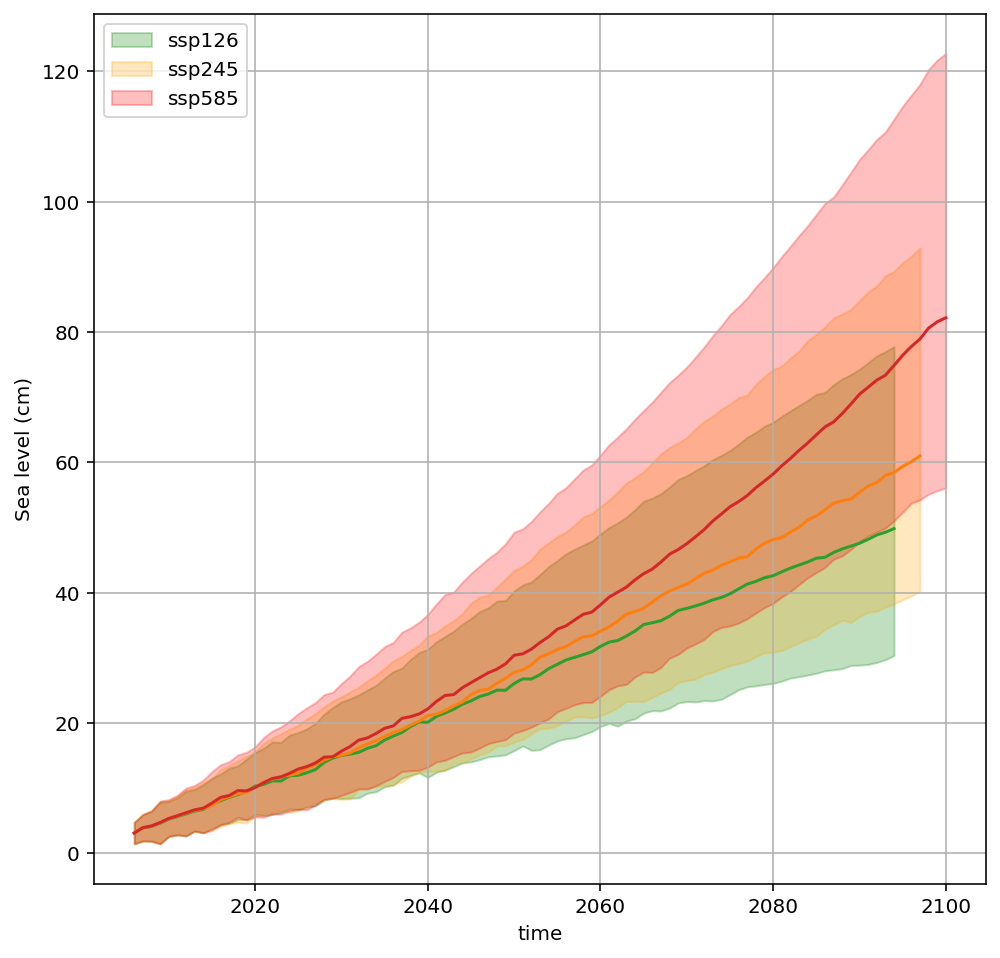

```python
make_proj_figure(KNMIsig_sub_26, KNMIsig_sub_45, KNMIsig_sub_85)

plt.title('');
```

## Backward extention

```python
def extend_da(da):
    '''Assume 0 values in 1995, the middle of the reference period and
    interpolate between 1995 and 2006'''

    sel_slice = da.isel(time=0).copy()
    sel_slice.values = np.zeros(sel_slice.shape)
    sel_slice['time'] = 1995
    sel_slice

    da_ext = xr.concat([sel_slice, da], dim='time')

    new_time = np.arange(da_ext.time[0].values.item(),
                         da_ext.time[-1].values.item()+1)

    da_ext = da_ext.interp(time=new_time, method="linear")

    return da_ext
```

```python
KNMIsig_sub_26_ext = extend_da(KNMIsig_sub_26)
KNMIsig_sub_45_ext = extend_da(KNMIsig_sub_45)
KNMIsig_sub_85_ext = extend_da(KNMIsig_sub_85)
```

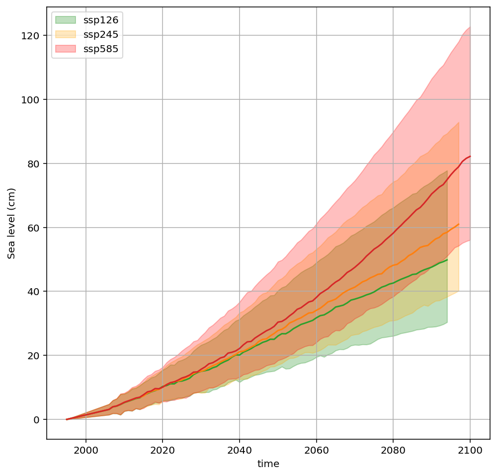

```python
make_proj_figure(KNMIsig_sub_26_ext, KNMIsig_sub_45_ext, KNMIsig_sub_85_ext)

plt.title('');
```

The assumption that all values are 0 in 1995 is fine for the median but even in 1995 there would be some model divergence so the uncertainty would not be 0 if computed in a consistent way.

However, this is the best that can be done now without modifying the sea level projection code.

## Check all sea level contributors

```python
def plot_contrib(da):

    nb_rows, nb_cols = 4, 4
    fig, axes = plt.subplots(nrows=nb_rows, ncols=nb_cols, figsize=(9,9))

    for i in range(len(da.proc)):
        da.isel(proc=i).sel(percentiles=[5,50,95]).plot.line(
            x='time', ax=axes.flat[i])
        axes.flat[i].set_ylabel('')
        axes.flat[i].set_title(da.proc[i].values)

        if i>0:
            legend = axes.flat[i].get_legend()
            legend.remove()

    for i in np.arange(len(da.proc), nb_rows*nb_cols):
        axes.flat[i].axis('off')

    plt.tight_layout()
```

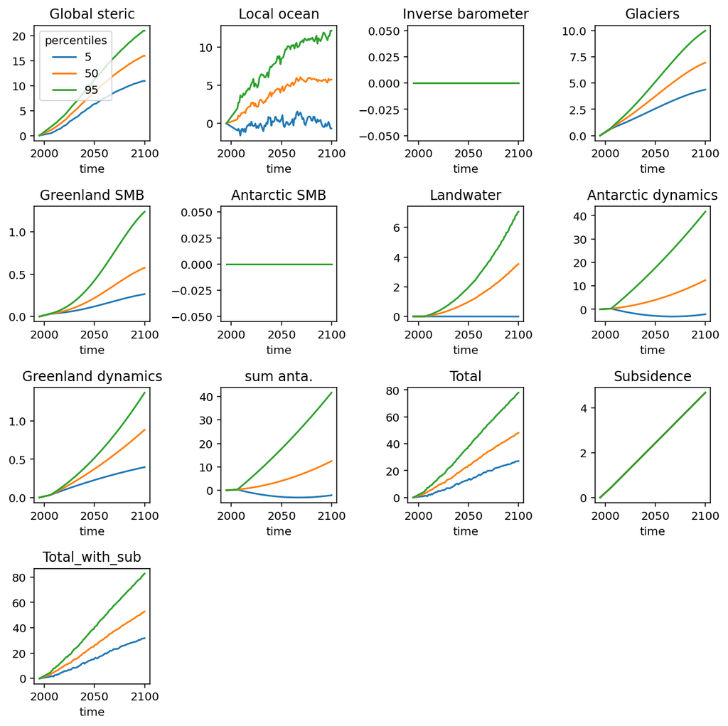

```python
plot_contrib(KNMIsig_sub_26_ext)
```

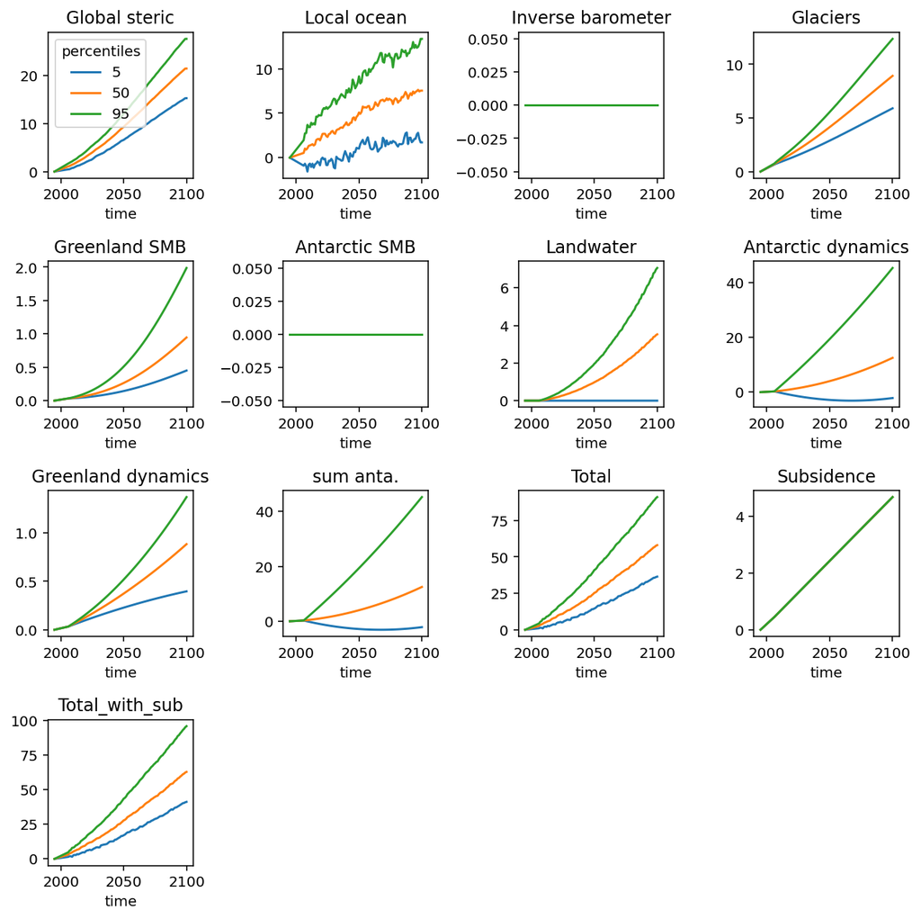

```python
plot_contrib(KNMIsig_sub_45_ext)
```

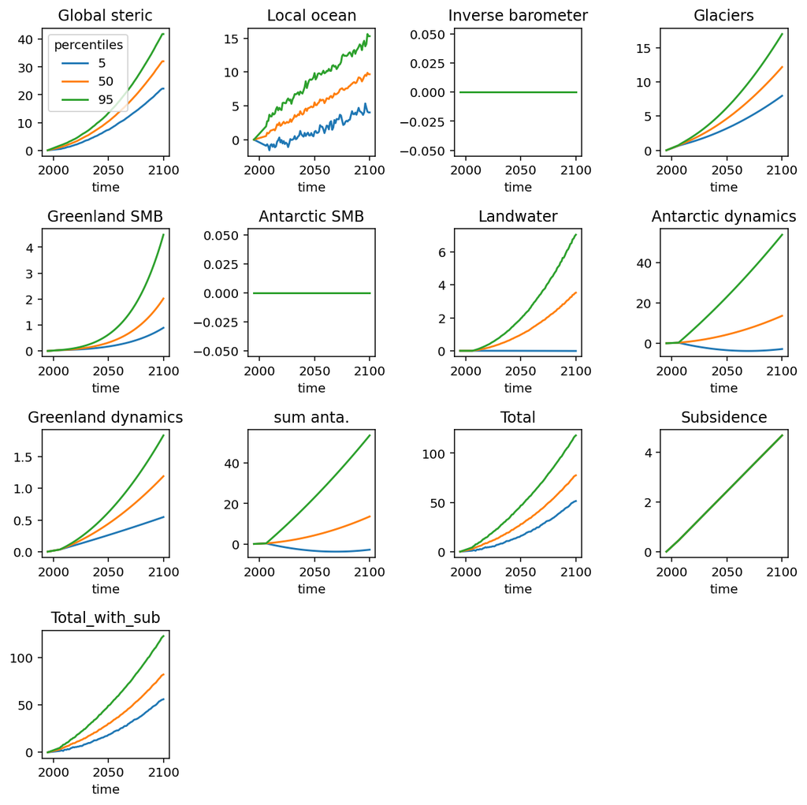

```python
plot_contrib(KNMIsig_sub_85_ext)
```

## Modify the reference period

```python
def new_ref_period(da):

    da_rp2 = da.sel(time=slice(2006,2100))
    da_rp2 = da_rp2 - da.sel(time=slice(1995,2014),percentiles=50).mean(dim='time')

    return da_rp2

KNMIsig_sub_26_ext_rp2 = new_ref_period(KNMIsig_sub_26_ext)
KNMIsig_sub_45_ext_rp2 = new_ref_period(KNMIsig_sub_45_ext)
KNMIsig_sub_85_ext_rp2 = new_ref_period(KNMIsig_sub_85_ext)
```

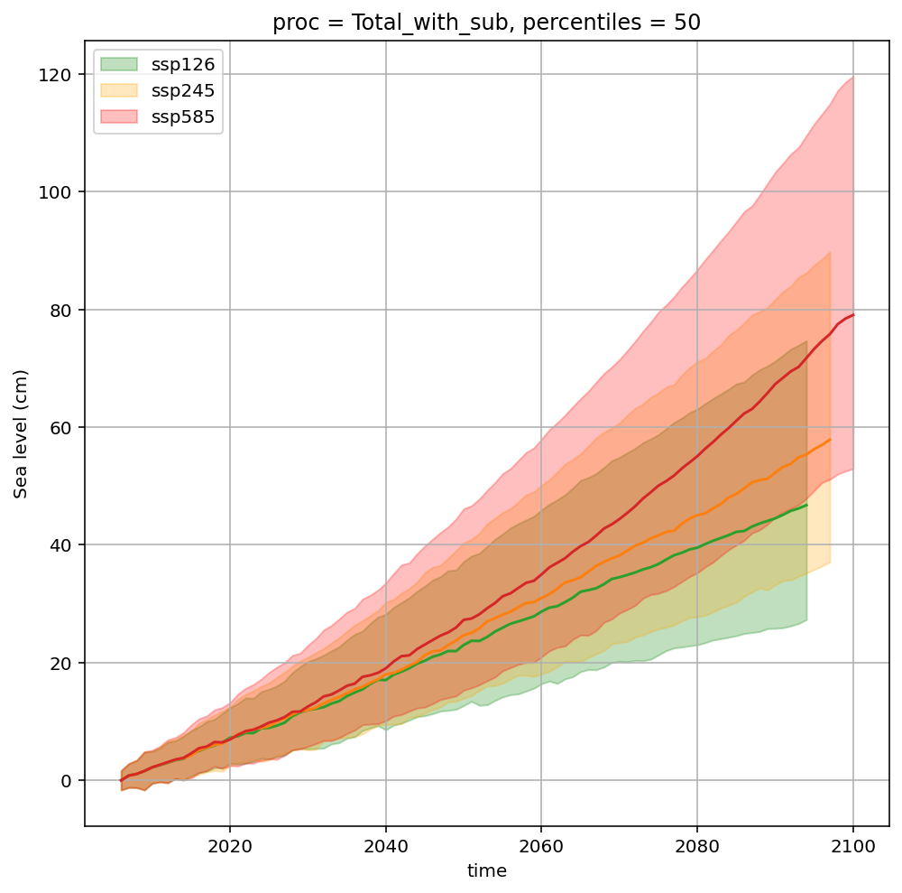

```python
make_proj_figure(KNMIsig_sub_26_ext_rp2, KNMIsig_sub_45_ext_rp2, KNMIsig_sub_85_ext_rp2)
```

```python
# Export NetCDF data
folder = './projections_all_contrib/'
sim = 'KNMIsignal_BiasCorr_NoWind_'
ref = '_ref_1995_2014.nc'

for scen in ['ssp126', 'ssp245', 'ssp585']:
    NameOutput = f'{folder}{sim}{scen}{ref}'
    if os.path.isfile(NameOutput):
        os.remove(NameOutput)

KNMIsig_sub_26_ext_rp2.to_netcdf(f'{folder}{sim}ssp126{ref}')
KNMIsig_sub_45_ext_rp2.to_netcdf(f'{folder}{sim}ssp245{ref}')
KNMIsig_sub_85_ext_rp2.to_netcdf(f'{folder}{sim}ssp585{ref}')
```

## Compare total sea level with official KS'21 time series

```python
path = './Klimaatsignaal2021_SeaLevel_MethodAndReproducibility/output_data/'
KS21_df = pd.read_csv(f'{path}DataKlimaatsignaal21_SeaLevel_2100_ref_period_1995_2014.csv')
KS21_df = KS21_df.set_index('time')
KS21_df
```

| time | Zeespiegelmonitor | Trend Zeespiegelmonitor | ssp126_5pc | ssp126_17pc | ssp126_50pc | ssp126_83pc | ssp126_95pc | ssp245_5pc | ssp245_17pc | ssp245_50pc | ssp245_83pc | ssp245_95pc | ssp585_5pc | ssp585_17pc | ssp585_50pc | ssp585_83pc | ssp585_95pc |
| --- | --- | --- | --- | --- | --- | --- | --- | --- | --- | --- | --- | --- | --- | --- | --- | --- | --- |
| 1890 | -23.655833 | -22.176018 | NaN | NaN | NaN | NaN | NaN | NaN | NaN | NaN | NaN | NaN | NaN | NaN | NaN | NaN | NaN |
| 1891 | -22.089167 | -21.950601 | NaN | NaN | NaN | NaN | NaN | NaN | NaN | NaN | NaN | NaN | NaN | NaN | NaN | NaN | NaN |
| 1892 | -20.839167 | -21.724294 | NaN | NaN | NaN | NaN | NaN | NaN | NaN | NaN | NaN | NaN | NaN | NaN | NaN | NaN | NaN |
| 1893 | -18.405833 | -21.496981 | NaN | NaN | NaN | NaN | NaN | NaN | NaN | NaN | NaN | NaN | NaN | NaN | NaN | NaN | NaN |
| 1894 | -18.372500 | -21.268622 | NaN | NaN | NaN | NaN | NaN | NaN | NaN | NaN | NaN | NaN | NaN | NaN | NaN | NaN | NaN |
| ... | ... | ... | ... | ... | ... | ... | ... | ... | ... | ... | ... | ... | ... | ... | ... | ... | ... |
| 2096 | NaN | NaN | 28.699153 | 36.454223 | 48.431710 | 64.307578 | 76.935607 | 37.542280 | 45.565005 | 58.123119 | 75.600366 | 89.681849 | 51.750131 | 61.016734 | 75.804137 | 97.009136 | 114.355788 |
| 2097 | NaN | NaN | 29.451888 | 37.338529 | 49.513578 | 65.584937 | 78.368411 | 38.203315 | 46.318179 | 59.018291 | 76.691092 | 90.930453 | 52.269549 | 61.785631 | 76.950299 | 98.423539 | 116.033730 |
| 2098 | NaN | NaN | 29.514395 | 37.494683 | 49.811483 | 66.063823 | 78.988716 | 38.375997 | 46.626617 | 59.527423 | 77.417450 | 91.825993 | 53.145112 | 62.987127 | 78.633519 | 100.403705 | 118.312862 |
| 2099 | NaN | NaN | 29.612818 | 37.818936 | 50.448660 | 66.944709 | 80.055195 | 38.886309 | 47.264064 | 60.354727 | 78.450246 | 93.033302 | 53.687838 | 63.701792 | 79.598088 | 101.621863 | 119.753277 |
| 2100 | NaN | NaN | 29.836999 | 38.094867 | 50.812870 | 67.468822 | 80.707032 | 39.169095 | 47.604724 | 60.793507 | 79.074927 | 93.799877 | 54.102428 | 64.188142 | 80.215248 | 102.466521 | 120.778975 |

211 rows × 17 columns

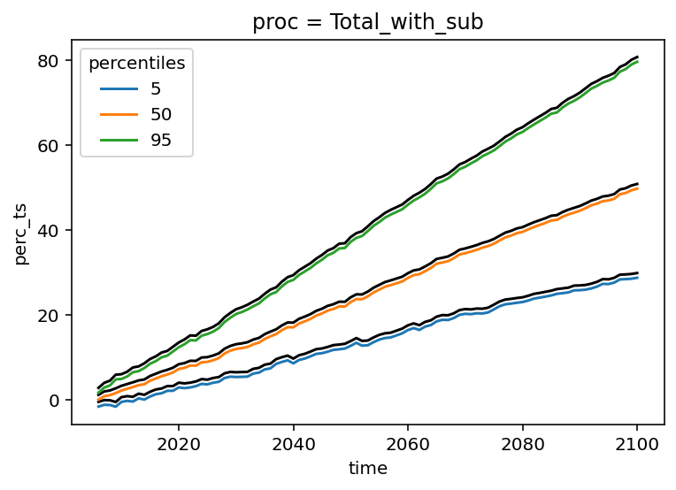

```python
KS21_df[['ssp126_5pc', 'ssp126_50pc', 'ssp126_95pc']].plot(color='black')
KNMIsig_sub_26_ext_rp2.sel(proc='Total_with_sub', percentiles=[5,50,95]).plot.line(x='time');
```

Official KS'21 in black and new method to adjust the reference period in colors.

```python
KS21_df['ssp245_5pc'].loc[2006:] - KNMIsig_sub_45_ext_rp2.sel(proc='Total_with_sub', percentiles=5)
```

```
time
2006    1.155343
2007    1.155343
2008    1.155343
2009    1.155343
2010    1.155343
          ...
2096    1.155343
2097    1.155343
2098    1.155343
2099    1.155343
2100    1.155343
Name: ssp245_5pc, Length: 95, dtype: float64
```

```python
rp = KNMIsig_sub_45_ext.sel(time=slice(1995,2014), percentiles=50, proc='Total_with_sub'
                           ).mean(dim='time').values.item()
print(f'{round(rp,2)} cm')
```

```
3.11 cm
```

While using the tide gauge observations it is:

```python
diff_ref_per = (KS21_df['Zeespiegelmonitor'].loc[1995:2014].mean() -
                KS21_df['Zeespiegelmonitor'].loc[1986:2005].mean())

print(f'{round(diff_ref_per,2)} cm')
```

```
1.95 cm
```